# Kunci Jawaban Soal Praktikum A

## Isyarat dan Sistem 2

### Topik 4 - Transformasi Laplace

# Daftar Isi

1. Jaringan Crossover Pasif
2. Lokasi Pole Sistem Orde-Dua

# I. Jaringan Crossover Pasif

## Nomor 1.1

Gunakan *voltage-divider* untuk mendapatkan fungsi alih sistem I

## Nomor 1.2

Ada 2 buah zero pada sistem tersebut, keduanya terletak di $0$.

```matlab
R = 10;
L = 2.2508*10^-4;
C = 1.1254*10^-6;
num = [R*L*C 0 0];
den = [R*L*C L R];
H1 = tf(num, den);
zero = roots(num)
pole = roots(den)
```

```
zero =

     0
     0


pole =

   1.0e+04 *

  -4.4429 + 4.4429i
  -4.4429 - 4.4429i
```

## Nomor 1.3

Peta *pole-zero*

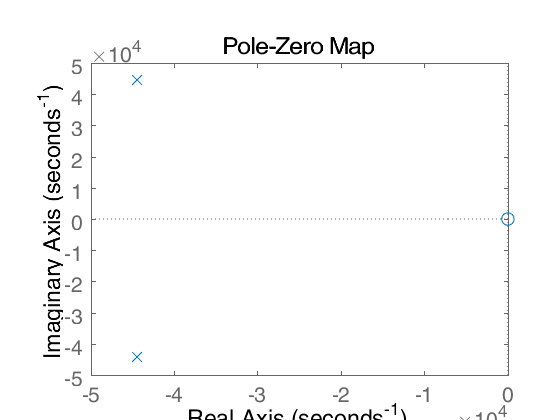

```matlab
pzmap(H1)
```

## Nomor 1.4

Ada 2 buah skenario ROC yang mungkin untuk sistem tersebut.

## Nomor 1.5

plot Bode

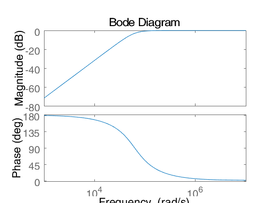

```matlab
bode(H1)
```

Berdasarkan plot Bode sistem I, terlihat bahwa sistem tersebut merupakan filter *high-pass*.

## Nomor 1.6

### Fungsi Alih Sistem II

Gunakan voltage-divider untuk mendapatkan fungsi alih sistem II

$$ H(s) = \frac{R}{sL + R} $$

### Letak *pole-zero* Sistem II

Ada satu buah zero pada sistem tersebut, terletak di $\infty$.

Ada satu buah pole pada sistem tersebut, terletak di $ -7.2253\times10^7$.

```matlab
R = 10;
L = 1.384*10^-7;
num = R;
den = [L R];
zero = roots(num)
pole = roots(den)
H2 = tf(num, den);
```

```
zero =

   Empty matrix: 0-by-1


pole =

  -7.2254e+07
```

### Peta *pole-zero* Sistem II

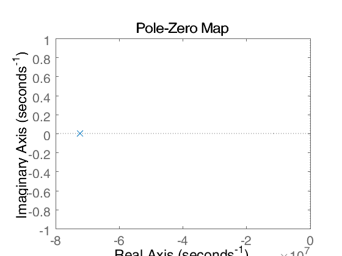

```matlab
pzmap(H2);
```

### ROC Sistem II

Ada 2 buah skenario ROC yang mungkin untuk sistem tersebut.

Skenario yang pertama adalah untuk kasus sistem yang stabil dan kausal. Jika sistem tersebut adalah sistem yang demikian, maka ROC sistem tersebut adalah $\Re(s) > -7.2254\times10^7$.

Skenario yang kedua adalah untuk kasus sistem yang tidak-stabil dan anti-kausal. Jika sistem tersebut adalah sistem yang demikian, maka ROC sistem tersebut adalah $\Re(s) < -7.2254\times10^7$.

### Plot Bode Sistem II

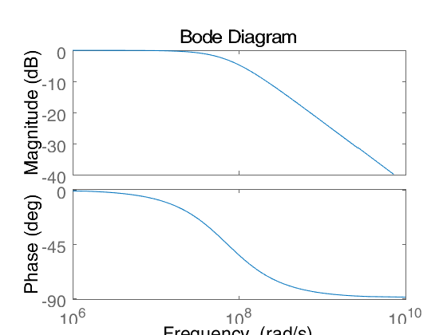

```matlab
bode(H2);
```

Berdasarkan plot Bode sistem I, terlihat bahwa sistem tersebut merupakan filter *low-pass*.

## Nomor 1.7

### Fungsi Alih Sistem X

Untuk kasus $H_1(s)$ di-*cascade* dengan $H_2(s)$, maka

$$ H_x(s) = \frac{s^2(2.533\times10^{-8})}{s^3(2.533\times10^{-9}) + s^2(0.1832) + s(1.627\times10^4) + 7.255\times10^8} $$

```matlab
Hx = H1*H2
```

```
Hx =

                   2.533e-08 s^2
  ------------------------------------------------
  3.506e-16 s^3 + 2.536e-08 s^2 + 0.002252 s + 100

Continuous-time transfer function.
```

### Letak *pole-zero* Sistem X

Ada 3 buah zero pada sistem tersebut, masing-masing terletak di $0$, $0$, dan $\infty$.

Ada 3 buah pole pada sistem tersebut, masing-masing terletak di $-7.2236\times10^7$, $(-0.0044+j0.0044)\times10^7$, dan $(-0.0044-j0.0044)\times10^7$.

```matlab
num = [0 2.533*10^-8 0 0];
den = [2.533*10^-9 0.1832 1.627*10^4 7.225*10^8];
zero = roots(num)
pole = roots(den)
```

```
zero =

     0
     0


pole =

   1.0e+07 *

  -7.2236 + 0.0000i
  -0.0044 + 0.0044i
  -0.0044 - 0.0044i
```

### Peta *pole-zero* Sistem X

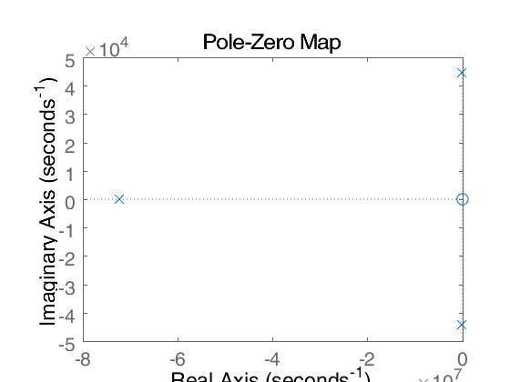

```matlab
pzmap(Hx);
```

### ROC Sistem X

Ada 2 buah skenario ROC yang mungkin untuk sistem tersebut.

Skenario yang pertama adalah untuk kasus sistem yang stabil dan kausal. Jika sistem tersebut adalah sistem yang demikian, maka ROC sistem tersebut adalah $\Re(s) > -0.0044\times10^7$.

Skenario yang kedua adalah untuk kasus sistem yang tidak-stabil dan anti-kausal. Jika sistem tersebut adalah sistem yang demikian, maka ROC sistem tersebut adalah $\Re(s) < -7.2236\times10^7$.

### Plot Bode Sistem X

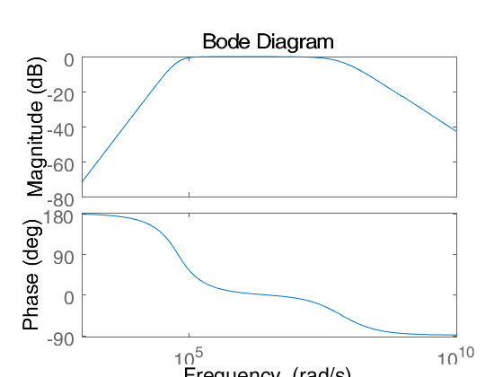

```matlab
bode(Hx);
```

Berdasarkan plot Bode sistem X, terlihat bahwa sistem tersebut merupakan filter *band-pass*.

## Nomor 1.8

### Fungsi Alih Sistem Y

Untuk kasus $H_1(s)$ diparalel dengan $H_2(s)$, maka

$$ H_y(s) = \frac{s^3(2.533\times10^{-9}) + s^2(0.366) + s(1.626\times10^4) + 7.255\times10^8}{s^3(2.533\times10^{-9}) + s^2(0.1832) + s(1.627\times10^4) + 7.255\times10^8} $$

```matlab
Hy = H1 + H2
```

```
Hy =

  3.506e-16 s^3 + 5.066e-08 s^2 + 0.002251 s + 100
  ------------------------------------------------
  3.506e-16 s^3 + 2.536e-08 s^2 + 0.002252 s + 100

Continuous-time transfer function.
```

### Letak pole-zero Sistem Y

Ada 3 buah zero pada sistem tersebut, masing-masing terletak di $-1.4445\times10^8$, $(-0.0002+j0.0004)\times10^8$, dan $(-0.0002+j0.0004)\times10^8$.

Ada 3 buah pole pada sistem tersebut, masing-masing terletak di $-7.2236\times10^7$, $(-0.0044+j0.0044)\times10^7$, dan $(-0.0044-j0.0044)\times10^7$.

```matlab
num = [2.533*10^-9 0.366 1.626*10^4 7.225*10^8];
den = [2.533*10^-9 0.1832 1.627*10^4 7.225*10^8];
zero = roots(num)
pole = roots(den)
```

```
zero =

   1.0e+08 *

  -1.4445 + 0.0000i
  -0.0002 + 0.0004i
  -0.0002 - 0.0004i


pole =

   1.0e+07 *

  -7.2236 + 0.0000i
  -0.0044 + 0.0044i
  -0.0044 - 0.0044i
```

### Peta *pole-zero* Sistem Y

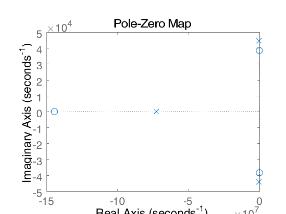

```matlab
pzmap(Hy);
```

### ROC Sistem Y

Ada 2 buah skenario ROC yang mungkin untuk sistem tersebut.

Skenario yang pertama adalah untuk kasus sistem yang stabil dan kausal. Jika sistem tersebut adalah sistem yang demikian, maka ROC sistem tersebut adalah $\Re(s) > -0.0044\times10^7$.

Skenario yang kedua adalah untuk kasus sistem yang tidak-stabil dan anti-kausal. Jika sistem tersebut adalah sistem yang demikian, maka ROC sistem tersebut adalah $\Re(s) < -7.2236\times10^7$.

### Plot Bode Sistem Y

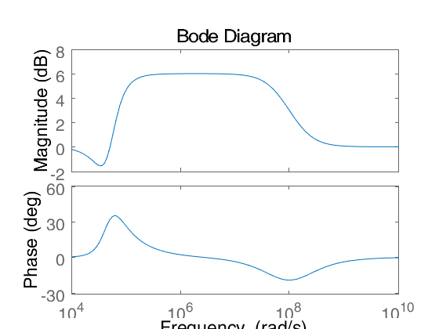

```matlab
bode(Hy);
```

Berdasarkan plot Bode sistem I, terlihat bahwa sistem tersebut merupakan filter *band-pass*.

## Nomor 1.9

Baik sistem X maupun sistem Y sama-sama berupa filter *band-pass*, namun kedua sistem tersebut memiliki sejumlah perbedaan. Perbedaan yang pertama adalah lebar pita sistem. Perbedaan yang kedua adalah pada sistem Y terdapat penguatan sebesar $+6\;\text{dB}$ pada frekuensi di dalam *band-pass*, sementara pada sistem X hanya sekedar meloloskan saja. Perbedaan yang ketiga adalah pada sistem Y terdapat *overshoot*, sementara pada sistem X tidak ada *overshoot*.

## Nomor 1.10

Untuk merancang filter *band-pass* yang paling gampang adalah dengan menggunakan 2 buah filter orde-pertama. Filter yang pertama adalah filter *low-pass* dengan frekuensi penggal di $20\;\text{kHz}$ sementara filter yang kedua adalah filter *high-pass* dengan frekuensi penggal di $2\;\text{kHz}$.

Fungsi alih untuk filter yang pertama adalah

$$ H_1(s) = \frac{\frac{1}{sC}}{R + \frac{1}{sC}} $$$$ H_1(s) = \frac{\frac{1}{sC}}{\frac{sRC + 1}{sC}} $$$$ H_1(s) =\frac{1}{sRC + 1} $$

Jika $R = 10\;\Omega$, maka $C = 7.958\times10^{-7}\;\text{F}$.

```matlab
R = 10;
C = 7.958*10^-7;
num = 1;
den = [R*C 1];
H1 = tf(num, den);
```

Fungsi alih untuk filter yang kedua adalah

$$ H_2(s) = \frac{sL}{sL + R} $$

Jika $R = 10\;\Omega$, maka $L = 7.958\times10^{-4}\;\text{H}$.

```matlab
R = 10;
L = 7.958*10^-4;
num = [L 0];
den = [L R];
H2 = tf(num, den);
```

Selanjutnya, kita *cascade* sistem I dan sistem II, sehingga

```matlab
H = H1*H2
```

```
H =

            0.0007958 s
  --------------------------------
  6.333e-09 s^2 + 0.0008754 s + 10

Continuous-time transfer function.
```

Kita cek plot Bode-nya

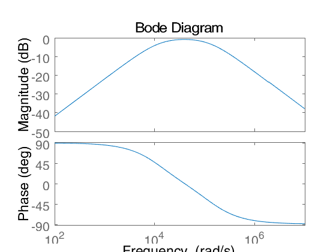

```matlab
bode(H);
```

Untuk *spin-off* kita coba masukkan lagu Handel. :D

```matlab
load handel;
t = 0 : 1/Fs : (length(y) - 1)/Fs;
a = lsim(H, y, t);
sound(a);
```

Bandingkan suara `a` dengan suara `y`!

```matlab
sound(y);
```

Suara lagu Handel yang asli lebih terasa bass-nya ketimbang suara lagu Handel yang terfilter tadi. Tentu saja demikian, karena kita hanya meloloskan sinyal audio dengan frekuensi tinggi, sementara frekuensi rendah (bass pada umumnya merupakan sinyal frekuensi rendah) ditolak (atau diatenuasi).

# II. Lokasi Pole Sistem Orde-Dua

## Nomor 2.1

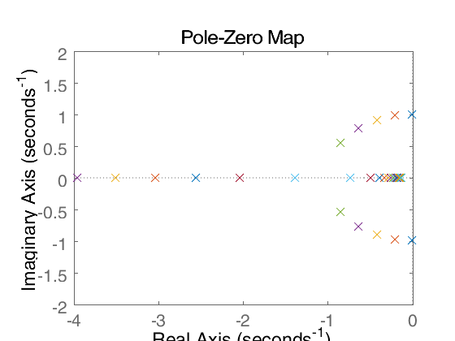

```matlab
zeta = linspace(0, 4, 20);
wn = 1;

den = zeros(1, length(zeta));
for i = 1 : length(zeta)
    num = wn^2;
    den(1, i) = 1;
    den(2, i) = 2*zeta(1,i)*wn;
    den(3, i) = wn^2;
end

for i = 1 : length(zeta)
    H = tf(num, transpose(den(:,i)));
    pzmap(H);
    hold on;
    axis equal;
    axis([-4 0 -2 2]);
    % k = waitforbuttonpress; % optional saja u/ keperluan animasi
end
```

Seperti yang sudah pernah kita pelajari sebelumnya, $\zeta$ mempengaruhi karakteristik redaman sistem.

Untuk $\zeta = 0$, kita perhatikan pole-nya murni imajiner! Itu berarti sistem tersebut menghasilkan tanggapan yang bersifat osilasi tanpa ada redaman.

Untuk $\zeta = 1$, kita perhatikan bahwa pole-nya terletak pada titik yang sama! (anda bisa modifikasi sedikit array zeta tersebut sehingga terdapat $\zeta = 1$). Itu berarti, sistem mulai tidak bersifat osilasi. Kita katakan redaman pada saat ini merupakan redaman kritis.

Untuk $\zeta > 1$, kita perhatikan bahwa pole-nya murni real! Itu berarti sistem tersebut tidak lagi memiliki tanggapan yang bersifat osilasi, namun sebaliknya memiliki redaman yang cukup besar.

## Nomor 2.2

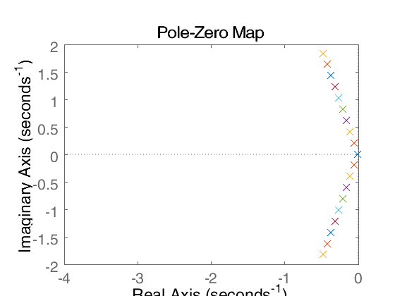

```matlab
zeta = 1/4;
wn = linspace(0, 4, 20);

num = zeros(1, length(wn));
den = zeros(3, length(wn));
for i = 1 : length(wn)
    num(1, i) = wn(1,i)^2;
    den(1, i) = 1;
    den(2, i) = 2*zeta*wn(1,i);
    den(3, i) = wn(1,i)^2;
end

for i = 1 : length(wn)
    H = tf(num(1,i), transpose(den(:,i)));
    pzmap(H);
    hold on;
    axis equal;
    axis([-4 0 -2 2]);
    % k = waitforbuttonpress; % optional saja u/ keperluan animasi
end
```

Seperti yang kita pelajari sebelumnya bahwa $\omega_n$ sebenarnya merupakan frekuensi natural sistem. Semakin tinggi $\omega_n$, maka semakin besar pula magnitude pole-nya. Kasus khusus untuk $\omega_n = 0$, kita perhatikan bahwa pole sistem pas terletak di titik *origin*, *which basically mean* sistem tersebut adalah filter *all-reject* (menolak semua jenis sinyal input, $H(s) = 0$).